# Invistico Airlines Project: 2nd case

**Objectives**  
*2nd case*  
The airline is interested in predicting whether a future customer would be satisfied with all of their services given previous customer feedback about their total flight experiences. The airline would like the construction and evaluation of a model that can accomplish this goal. They are also interested in knowing which features of the total flight experience are most important to customer satisfaction.

**Deliverables**  
The data is sample size of survey responses from 129,880 customers. It includes data points such as satisfaction, class, flight distance, and inflight entertainment, among others. It is an in-house product.

*Models*  
(Since this project is a portfolio addition, the models are predetermined. Since this is a labelled data set, all models qualify as supervised.)

2nd case: **Tree-based classification machine learning model** (2nd notebook)  
In the second case, the airline is interested in predicting whether a future customer would be satisfied with their flight experience given previous customer feedback. They are also interested in knowing which features of their flight experience are most predictive of that satisfaction. Decision trees are classification models that can handle all of the types of variables this data set contains (categorical, discrete, and continuous). They make predictions for a target variable based on multiple variables (features). Because decision trees return a weighted map of possible outcomes to any series of related choices, the airline can use these findings to allot their available resources.

For this second case 3 tree based models are trained, tuned, evaluated, and compared for the most predictive power. The most predictive will be tested on the unseen test data.\

The goal will be to utilize the best decision tree model to predict whether or not a customer will be *satisfied(y)* with their flight experience based on multiple variables in the data set(Xs) and discover which variables are most predictive of that outcome.

#### Import packages

```python
# Import standard operational packages
import numpy as np
import pandas as pd

# Import preprocessing, modeling, and evaluation packages
from sklearn.preprocessing import OneHotEncoder
from sklearn.model_selection import train_test_split, GridSearchCV, PredefinedSplit
from sklearn.tree import DecisionTreeClassifier
from sklearn.metrics import recall_score, precision_score, f1_score, accuracy_score, classification_report
from sklearn.ensemble import RandomForestClassifier

# Import from xgboost
from xgboost import XGBClassifier
from xgboost import plot_importance

# Import visualization package
import matplotlib.pyplot as plt
import seaborn as sns
from sklearn.tree import plot_tree
from sklearn.metrics import confusion_matrix, ConfusionMatrixDisplay, RocCurveDisplay, roc_auc_score

# Save models once fitted.
import pickle

# Set Jupyter to display all of the columns (no redaction)
pd.set_option('display.max_columns', None)
```

```python
# Import data; create df
df0 = pd.read_csv('transformed_invistico.csv', on_bad_lines='skip')
df0.head()
```

|  | Satisfaction | Customer Type | Age | Type of Travel | Class | Flight Distance | Seat comfort | Departure/Arrival time convenient | Food and drink | Gate location | Inflight wifi service | Inflight entertainment | Online support | Ease of Online booking | On-board service | Leg room service | Baggage handling | Checkin service | Cleanliness | Online boarding | Departure Delay in Minutes | Arrival Delay in Minutes |
| --- | --- | --- | --- | --- | --- | --- | --- | --- | --- | --- | --- | --- | --- | --- | --- | --- | --- | --- | --- | --- | --- | --- |
| 0 | 1 | Loyal Customer | 65 | Personal Travel | Eco | 265 | 0 | 0 | 0 | 2 | 2 | 4.0 | 2 | 3 | 3 | 0 | 3 | 5 | 3 | 2 | 0 | 0.0 |
| 1 | 1 | Loyal Customer | 47 | Personal Travel | Business | 2464 | 0 | 0 | 0 | 3 | 0 | 2.0 | 2 | 3 | 4 | 4 | 4 | 2 | 3 | 2 | 310 | 305.0 |
| 2 | 1 | Loyal Customer | 15 | Personal Travel | Eco | 2138 | 0 | 0 | 0 | 3 | 2 | 0.0 | 2 | 2 | 3 | 3 | 4 | 4 | 4 | 2 | 0 | 0.0 |
| 3 | 1 | Loyal Customer | 60 | Personal Travel | Eco | 623 | 0 | 0 | 0 | 3 | 3 | 4.0 | 3 | 1 | 1 | 0 | 1 | 4 | 1 | 3 | 0 | 0.0 |
| 4 | 1 | Loyal Customer | 70 | Personal Travel | Eco | 354 | 0 | 0 | 0 | 3 | 4 | 3.0 | 4 | 2 | 2 | 0 | 2 | 4 | 2 | 5 | 0 | 0.0 |

## PART I: BASIC EDA revisted

Examine transformed data set for what it does and does not say

```python
# Investigate df
df0.info()
```

```
<class 'pandas.core.frame.DataFrame'>
RangeIndex: 129487 entries, 0 to 129486
Data columns (total 22 columns):
 #   Column                             Non-Null Count   Dtype
---  ------                             --------------   -----
 0   Satisfaction                       129487 non-null  int64
 1   Customer Type                      129487 non-null  object
 2   Age                                129487 non-null  int64
 3   Type of Travel                     129487 non-null  object
 4   Class                              129487 non-null  object
 5   Flight Distance                    129487 non-null  int64
 6   Seat comfort                       129487 non-null  int64
 7   Departure/Arrival time convenient  129487 non-null  int64
 8   Food and drink                     129487 non-null  int64
 9   Gate location                      129487 non-null  int64
 10  Inflight wifi service              129487 non-null  int64
 11  Inflight entertainment             129487 non-null  float64
 12  Online support                     129487 non-null  int64
 13  Ease of Online booking             129487 non-null  int64
 14  On-board service                   129487 non-null  int64
 15  Leg room service                   129487 non-null  int64
 16  Baggage handling                   129487 non-null  int64
 17  Checkin service                    129487 non-null  int64
 18  Cleanliness                        129487 non-null  int64
 19  Online boarding                    129487 non-null  int64
 20  Departure Delay in Minutes         129487 non-null  int64
 21  Arrival Delay in Minutes           129487 non-null  float64
dtypes: float64(2), int64(17), object(3)
memory usage: 21.7+ MB
```

```python
df0.describe()
```

|  | Satisfaction | Age | Flight Distance | Seat comfort | Departure/Arrival time convenient | Food and drink | Gate location | Inflight wifi service | Inflight entertainment | Online support | Ease of Online booking | On-board service | Leg room service | Baggage handling | Checkin service | Cleanliness | Online boarding | Departure Delay in Minutes | Arrival Delay in Minutes |
| --- | --- | --- | --- | --- | --- | --- | --- | --- | --- | --- | --- | --- | --- | --- | --- | --- | --- | --- | --- |
| count | 129487.000000 | 129487.000000 | 129487.000000 | 129487.000000 | 129487.000000 | 129487.000000 | 129487.000000 | 129487.000000 | 129487.000000 | 129487.000000 | 129487.000000 | 129487.000000 | 129487.000000 | 129487.000000 | 129487.000000 | 129487.000000 | 129487.000000 | 129487.000000 | 129487.000000 |
| mean | 0.547406 | 39.428761 | 1981.008974 | 2.838586 | 2.990277 | 2.852024 | 2.990377 | 3.249160 | 3.383745 | 3.519967 | 3.472171 | 3.465143 | 3.486118 | 3.695460 | 3.340729 | 3.705886 | 3.352545 | 14.643385 | 15.091129 |
| std | 0.497749 | 15.117597 | 1026.884131 | 1.392873 | 1.527183 | 1.443587 | 1.305917 | 1.318765 | 1.345959 | 1.306326 | 1.305573 | 1.270755 | 1.292079 | 1.156487 | 1.260561 | 1.151683 | 1.298624 | 37.932867 | 38.465650 |
| min | 0.000000 | 7.000000 | 50.000000 | 0.000000 | 0.000000 | 0.000000 | 0.000000 | 0.000000 | 0.000000 | 0.000000 | 0.000000 | 0.000000 | 0.000000 | 1.000000 | 0.000000 | 0.000000 | 0.000000 | 0.000000 | 0.000000 |
| 25% | 0.000000 | 27.000000 | 1359.000000 | 2.000000 | 2.000000 | 2.000000 | 2.000000 | 2.000000 | 2.000000 | 3.000000 | 2.000000 | 3.000000 | 2.000000 | 3.000000 | 3.000000 | 3.000000 | 2.000000 | 0.000000 | 0.000000 |
| 50% | 1.000000 | 40.000000 | 1924.000000 | 3.000000 | 3.000000 | 3.000000 | 3.000000 | 3.000000 | 4.000000 | 4.000000 | 4.000000 | 4.000000 | 4.000000 | 4.000000 | 3.000000 | 4.000000 | 4.000000 | 0.000000 | 0.000000 |
| 75% | 1.000000 | 51.000000 | 2543.000000 | 4.000000 | 4.000000 | 4.000000 | 4.000000 | 4.000000 | 4.000000 | 5.000000 | 5.000000 | 4.000000 | 5.000000 | 5.000000 | 4.000000 | 5.000000 | 4.000000 | 12.000000 | 13.000000 |
| max | 1.000000 | 85.000000 | 6951.000000 | 5.000000 | 5.000000 | 5.000000 | 5.000000 | 5.000000 | 5.000000 | 5.000000 | 5.000000 | 5.000000 | 5.000000 | 5.000000 | 5.000000 | 5.000000 | 5.000000 | 1592.000000 | 1584.000000 |

```python
# Check for missing values
print(df0.isnull().sum())
df0.shape
```

```
Satisfaction                         0
Customer Type                        0
Age                                  0
Type of Travel                       0
Class                                0
Flight Distance                      0
Seat comfort                         0
Departure/Arrival time convenient    0
Food and drink                       0
Gate location                        0
Inflight wifi service                0
Inflight entertainment               0
Online support                       0
Ease of Online booking               0
On-board service                     0
Leg room service                     0
Baggage handling                     0
Checkin service                      0
Cleanliness                          0
Online boarding                      0
Departure Delay in Minutes           0
Arrival Delay in Minutes             0
dtype: int64
```

```
(129487, 22)
```

#### Initial summary

```python
# Retype Departure Delay in Minutes as float
# Create new df
df = df0.astype({'Departure Delay in Minutes': float})
df.dtypes
```

```
Satisfaction                           int64
Customer Type                         object
Age                                    int64
Type of Travel                        object
Class                                 object
Flight Distance                        int64
Seat comfort                           int64
Departure/Arrival time convenient      int64
Food and drink                         int64
Gate location                          int64
Inflight wifi service                  int64
Inflight entertainment               float64
Online support                         int64
Ease of Online booking                 int64
On-board service                       int64
Leg room service                       int64
Baggage handling                       int64
Checkin service                        int64
Cleanliness                            int64
Online boarding                        int64
Departure Delay in Minutes           float64
Arrival Delay in Minutes             float64
dtype: object
```

### Feature engineering

#### Output unique values

```python
# Check class balance for target variable
print(df['Satisfaction'].value_counts())
print(df['Satisfaction'].value_counts(normalize=True))
```

```
Satisfaction
1    70882
0    58605
Name: count, dtype: int64
Satisfaction
1    0.547406
0    0.452594
Name: proportion, dtype: float64
```

```python
# Check class balance for Customer Type
print (df['Customer Type'].value_counts())
print (df['Customer Type'].value_counts(normalize=True))
```

```
Customer Type
Loyal Customer       105773
disloyal Customer     23714
Name: count, dtype: int64
Customer Type
Loyal Customer       0.816862
disloyal Customer    0.183138
Name: proportion, dtype: float64
```

```python
# Check class balance for Type of Travel
print (df['Type of Travel'].value_counts())
print (df['Type of Travel'].value_counts(normalize=True))
```

```
Type of Travel
Business travel    89445
Personal Travel    40042
Name: count, dtype: int64
Type of Travel
Business travel    0.690764
Personal Travel    0.309236
Name: proportion, dtype: float64
```

```python
# Check class balance for Class
print (df['Class'].value_counts())
print (df['Class'].value_counts(normalize=True))
```

```
Class
Business    61990
Eco         58117
Eco Plus     9380
Name: count, dtype: int64
Class
Business    0.478735
Eco         0.448825
Eco Plus    0.072440
Name: proportion, dtype: float64
```

### Output unique values

**Satisfaction: 2 choices**

*Customer Type: 2 choices*: this is imbalanced; Hotencoded

- Loyal Customer 105773 (~0.82%)
- disloyal Customer 23714 (~0.18%)

*Type of Travel: 2 choices*: Hotencoded

- Business travel 89445 (~0.69%)
- Personal Travel 40042 (~0.31%)

*Class: 3 choices*: this will be Hotencoded to form 2 more balanced classes

- Business 61990 (~0.48%)
- Eco 58117 (~0.45%)
- Eco Plus 9380 (~0.072%)

### Encode data

Encode object variables: 'Customer Type', 'Type of Travel', 'Class'. Decision trees need numeric columns, so these must be converted to ordinals.

The target variable 'Satisfaction' has already been encoded

```python
# HotEncode Class to 2 categories
df['Class'] = OneHotEncoder().fit_transform(df[['Class']]).toarray()
df.head()
```

|  | Satisfaction | Customer Type | Age | Type of Travel | Class | Flight Distance | Seat comfort | Departure/Arrival time convenient | Food and drink | Gate location | Inflight wifi service | Inflight entertainment | Online support | Ease of Online booking | On-board service | Leg room service | Baggage handling | Checkin service | Cleanliness | Online boarding | Departure Delay in Minutes | Arrival Delay in Minutes |
| --- | --- | --- | --- | --- | --- | --- | --- | --- | --- | --- | --- | --- | --- | --- | --- | --- | --- | --- | --- | --- | --- | --- |
| 0 | 1 | Loyal Customer | 65 | Personal Travel | 0.0 | 265 | 0 | 0 | 0 | 2 | 2 | 4.0 | 2 | 3 | 3 | 0 | 3 | 5 | 3 | 2 | 0.0 | 0.0 |
| 1 | 1 | Loyal Customer | 47 | Personal Travel | 1.0 | 2464 | 0 | 0 | 0 | 3 | 0 | 2.0 | 2 | 3 | 4 | 4 | 4 | 2 | 3 | 2 | 310.0 | 305.0 |
| 2 | 1 | Loyal Customer | 15 | Personal Travel | 0.0 | 2138 | 0 | 0 | 0 | 3 | 2 | 0.0 | 2 | 2 | 3 | 3 | 4 | 4 | 4 | 2 | 0.0 | 0.0 |
| 3 | 1 | Loyal Customer | 60 | Personal Travel | 0.0 | 623 | 0 | 0 | 0 | 3 | 3 | 4.0 | 3 | 1 | 1 | 0 | 1 | 4 | 1 | 3 | 0.0 | 0.0 |
| 4 | 1 | Loyal Customer | 70 | Personal Travel | 0.0 | 354 | 0 | 0 | 0 | 3 | 4 | 3.0 | 4 | 2 | 2 | 0 | 2 | 4 | 2 | 5 | 0.0 | 0.0 |

```python
# Check class balance for Class
print (df['Class'].value_counts())
print (df['Class'].value_counts(normalize=True))
```

```
Class
0.0    67497
1.0    61990
Name: count, dtype: int64
Class
0.0    0.521265
1.0    0.478735
Name: proportion, dtype: float64
```

```python
# HotEncode Type of Travel and Customer Type
df['Type of Travel'] = OneHotEncoder().fit_transform(df[['Type of Travel']]).toarray()
df['Customer Type'] = OneHotEncoder().fit_transform(df[['Customer Type']]).toarray()
```

```python
print (df['Type of Travel'].value_counts())
print (df['Customer Type'].value_counts())
```

```
Type of Travel
1.0    89445
0.0    40042
Name: count, dtype: int64
Customer Type
1.0    105773
0.0     23714
Name: count, dtype: int64
```

Result  
*Type of Travel: 2 choices*

- Business travel 89445 = 1
- Personal Travel 40042 = 0

*Customer Type: 2 choices*

- Loyal Customer 105773 = 1
- disloyal Customer 23714 = 0

```python
df.head()
```

|  | Satisfaction | Customer Type | Age | Type of Travel | Class | Flight Distance | Seat comfort | Departure/Arrival time convenient | Food and drink | Gate location | Inflight wifi service | Inflight entertainment | Online support | Ease of Online booking | On-board service | Leg room service | Baggage handling | Checkin service | Cleanliness | Online boarding | Departure Delay in Minutes | Arrival Delay in Minutes |
| --- | --- | --- | --- | --- | --- | --- | --- | --- | --- | --- | --- | --- | --- | --- | --- | --- | --- | --- | --- | --- | --- | --- |
| 0 | 1 | 1.0 | 65 | 0.0 | 0.0 | 265 | 0 | 0 | 0 | 2 | 2 | 4.0 | 2 | 3 | 3 | 0 | 3 | 5 | 3 | 2 | 0.0 | 0.0 |
| 1 | 1 | 1.0 | 47 | 0.0 | 1.0 | 2464 | 0 | 0 | 0 | 3 | 0 | 2.0 | 2 | 3 | 4 | 4 | 4 | 2 | 3 | 2 | 310.0 | 305.0 |
| 2 | 1 | 1.0 | 15 | 0.0 | 0.0 | 2138 | 0 | 0 | 0 | 3 | 2 | 0.0 | 2 | 2 | 3 | 3 | 4 | 4 | 4 | 2 | 0.0 | 0.0 |
| 3 | 1 | 1.0 | 60 | 0.0 | 0.0 | 623 | 0 | 0 | 0 | 3 | 3 | 4.0 | 3 | 1 | 1 | 0 | 1 | 4 | 1 | 3 | 0.0 | 0.0 |
| 4 | 1 | 1.0 | 70 | 0.0 | 0.0 | 354 | 0 | 0 | 0 | 3 | 4 | 3.0 | 4 | 2 | 2 | 0 | 2 | 4 | 2 | 5 | 0.0 | 0.0 |

```python
# Check column data types
df.dtypes
```

```
Satisfaction                           int64
Customer Type                        float64
Age                                    int64
Type of Travel                       float64
Class                                float64
Flight Distance                        int64
Seat comfort                           int64
Departure/Arrival time convenient      int64
Food and drink                         int64
Gate location                          int64
Inflight wifi service                  int64
Inflight entertainment               float64
Online support                         int64
Ease of Online booking                 int64
On-board service                       int64
Leg room service                       int64
Baggage handling                       int64
Checkin service                        int64
Cleanliness                            int64
Online boarding                        int64
Departure Delay in Minutes           float64
Arrival Delay in Minutes             float64
dtype: object
```

```python
# Export the new df
df.to_csv('transformed_invistico2.csv', index=0)
```

```python
# Check new csv was created
df = pd.read_csv('transformed_invistico2.csv')
df.head()
```

|  | Satisfaction | Customer Type | Age | Type of Travel | Class | Flight Distance | Seat comfort | Departure/Arrival time convenient | Food and drink | Gate location | Inflight wifi service | Inflight entertainment | Online support | Ease of Online booking | On-board service | Leg room service | Baggage handling | Checkin service | Cleanliness | Online boarding | Departure Delay in Minutes | Arrival Delay in Minutes |
| --- | --- | --- | --- | --- | --- | --- | --- | --- | --- | --- | --- | --- | --- | --- | --- | --- | --- | --- | --- | --- | --- | --- |
| 0 | 1 | 1.0 | 65 | 0.0 | 0.0 | 265 | 0 | 0 | 0 | 2 | 2 | 4.0 | 2 | 3 | 3 | 0 | 3 | 5 | 3 | 2 | 0.0 | 0.0 |
| 1 | 1 | 1.0 | 47 | 0.0 | 1.0 | 2464 | 0 | 0 | 0 | 3 | 0 | 2.0 | 2 | 3 | 4 | 4 | 4 | 2 | 3 | 2 | 310.0 | 305.0 |
| 2 | 1 | 1.0 | 15 | 0.0 | 0.0 | 2138 | 0 | 0 | 0 | 3 | 2 | 0.0 | 2 | 2 | 3 | 3 | 4 | 4 | 4 | 2 | 0.0 | 0.0 |
| 3 | 1 | 1.0 | 60 | 0.0 | 0.0 | 623 | 0 | 0 | 0 | 3 | 3 | 4.0 | 3 | 1 | 1 | 0 | 1 | 4 | 1 | 3 | 0.0 | 0.0 |
| 4 | 1 | 1.0 | 70 | 0.0 | 0.0 | 354 | 0 | 0 | 0 | 3 | 4 | 3.0 | 4 | 2 | 2 | 0 | 2 | 4 | 2 | 5 | 0.0 | 0.0 |

```python
df.shape
```

```
(129487, 22)
```

## PART III: 2nd CASE

## Build 3 tree-based classification machine learning models

### 1. Build baseline decision tree

- Train a baseline model to get a sense of how predictive the data is
- Get data points(scores) that can be referenced later

#### Prepare data for modelling

Split the data into:

- features and target variable
- training data(75%) and test data(25%)
- no need to stratify, because data set is balanced
- set a random seed so work can be reproduced (0)

```python
# Subset data in dependent y(target) and independent X variables(features)
y = df['Satisfaction']
X = df.drop('Satisfaction', axis = 1)
```

#### Modelling

- choose model
- fit data to model
- evaluate model

Decision trees require no assumptions regarding the distribution of underlying data and don't require scaling of features, so do not need to check balances or visualize how well variables align with normal distribution

```python
# Split into train and test sets
X_train, X_test, y_train, y_test = train_test_split(X, y, test_size=0.25, random_state=0)
```

```python
# Verify shape of splits
print(X_train.shape)
print(X_test.shape)
print(y_train.shape)
print(y_test.shape)
```

```
(97115, 21)
(32372, 21)
(97115,)
(32372,)
```

```python
# Check balance of test set
y_test.value_counts()
```

```
Satisfaction
1    17730
0    14642
Name: count, dtype: int64
```

```python
# Instantiate model. Set random_state=0 so same results when code rerun
decision_tree = DecisionTreeClassifier(random_state=0)

# Fit a decision tree classifier model to the training data
decision_tree.fit(X_train, y_train)
DT_pred = decision_tree.predict(X_test) # assign predict() to new variable dt_pred
```

### Evaluate baseline model on test data

- Visualize predictions
- Generate performance metrics

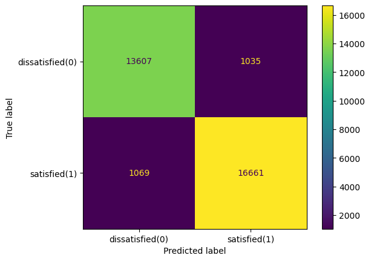

```python
# Create confusion matrix to visualize how accurate classifier is at predicting the labels
# Calculate the values for each quadrant in the confusion matrix
cm = confusion_matrix(y_test, DT_pred, labels = decision_tree.classes_) # decision_tree.classes_ (classifications)

# Visualize confusion matrix
disp = ConfusionMatrixDisplay(confusion_matrix = cm, display_labels=['dissatisfied(0)', 'satisfied(1)']) # display_labels = clf.classes_

disp.plot();
```

*Legend*

- True label (y_test): actual labels of the holdout sample
- Predicted label (DT_pred): predicted labels (satisfied/dissatisfied [decision_tree.classes_]) on the holdout test sample

- 0 = the person was labeled as dissatisfied for that observation
- 1 = a person was labeled as satisfied for that observation

*Translation*

- True negatives(UL): # of people that were dissatisfied(0) that the model accurately predicted as dissatisfied(0) = 13607
- True positives(LR): # of people that were satisfied(1) that the model accurately predicted were satisfied(1) = 16661
- False positives(UR)/ Type I Errors: # of people that were dissatisfied(0) that the model inaccurately predicted were satisfied(1) = 1035
- False negatives(LL)/Type II Errors: # of people that were satisfied(1) that the model inaccurately predicted were dissatisfied(0) = 1069

Immediately seen from the model is a very high proportion of true positives and true negatives (where the matrix accurately predicted that the customer would be satisfied or dissatisfied, respectively) to false positives and false negatives.

There is also a proportional relationship between false positives and false negatives (where the matrix inaccurately predicted that the customer would be satisfied or dissatisfied, respectively. There are very few false positives and false negatives.

```python
# Create table of results for metrics
# precision_score(y_test, DT_pred) = Y values in holdout testing dataset &  Y values that model predicted from the X values in holdout test dataset
result_table = pd.DataFrame({'Model': [decision_tree],
                      'Precision': ['%.6f' % precision_score(y_test, DT_pred)],
                      'Recall': ['%.6f' % recall_score(y_test, DT_pred)],
                      'Accuracy': ['%.6f' % accuracy_score(y_test, DT_pred)],
                      'F1': ['%.6f' % f1_score(y_test, DT_pred)]
                     })
DT = result_table
DT
```

|  | Model | Precision | Recall | Accuracy | F1 |
| --- | --- | --- | --- | --- | --- |
| 0 | DecisionTreeClassifier(random_state=0) | 0.941512 | 0.939707 | 0.935006 | 0.940609 |

```python
# Create a classification report
target_labels = ['dissatisfied', 'satisfied']
print(classification_report(y_test, DT_pred, target_names = target_labels))
```

```
              precision    recall  f1-score   support

dissatisfied       0.93      0.93      0.93     14642
   satisfied       0.94      0.94      0.94     17730

    accuracy                           0.94     32372
   macro avg       0.93      0.93      0.93     32372
weighted avg       0.94      0.94      0.94     32372
```

**Precision**: measures the % of customers that are actually satisfied out of all the customers that have been predicted to be satisfied (# true positives(16661) / (# true positives(16661) + # false positives(1035))

*The good*  
This model has a precision score of 0.94, thus it is excellent at precisely predicting whether an airline customer will be satisfied (true positives), based on the feature variables. In an effort to be precise, the model also attempts to reduce the occurrences of incorrectly classifying people as satisfied when they are dissatisfied (false positives/Type I errors).

*The bad*  
In its goal to be precise (not classify people as satisfied when they are dissatisfied), the algorithm can become more selective. A higher rate of precision may mean that more samples are classified as dissatisfied, when then are satisfied (false-negative/Type II errors). Thus, satisfied customers can be missed, especially with such a high precision score.

The conclusion:  
Because the airline is interested in learning if a new customer would be satisfied based on their current inflight entertainment, an 94% satisfaction rate is excellent. This is particularly true if the algorithm has even missed satisfied people.

*The bad*  
However, because the model is more sensitive to finding satisfied people, it can be prone to incorrectly categorizing people as satisfied (false-positives/Type-I error) when they are dissatisfied.

*The bad*  
Accuracy can be misleading if the data set is unbalanced. The algorithm could be poor at balancing false positive and false negatives because it does not account for the distribution of classes (satisfied/dissatisfied). It could be excellent at predicting one class (e.g., the majority) and being terrible at predicting the other (e.g., the minority) and return a very good accuracy score.

The conclusion  
Since this class was mostly balanced (17730 (1)/ 14642 (0)), an accuracy of ~0.94 likely reflects a well balanced result.

**F1 Score** (the harmonic mean) balances precision (minimizing false positives or Type I errors) and recall (minimizing false negatives or Type II errors) performance, providing a single value for evaluation.

The conclusion  
The combined F1 score of 0.94 is excellent. It means that the model is highly effective at minimizing both type of errors. However, because decision trees are prone to overfitting, this result is a bit suspect.

```python
# Read in master results table
results = pd.read_csv('Satisfaction_Results.csv')
results
```

|  | Model | Precision | Recall | Accuracy | F1 |
| --- | --- | --- | --- | --- | --- |
| 0 | LogisticRegression | 0.816142 | 0.82153 | 0.801529 | 0.818827 |

```python
# Concatentate decision tree model results table with master results table
results = pd.concat([DT, results])
results
```

|  | Model | Precision | Recall | Accuracy | F1 |
| --- | --- | --- | --- | --- | --- |
| 0 | DecisionTreeClassifier(random_state=0) | 0.941512 | 0.939707 | 0.935006 | 0.940609 |
| 0 | LogisticRegression | 0.816142 | 0.82153 | 0.801529 | 0.818827 |

```python
# Save results table as csv
results.to_csv('Satisfaction_Results.csv', index = False)
```

```python
# View the results
table = pd.read_csv('Satisfaction_Results.csv')
table.head()
```

|  | Model | Precision | Recall | Accuracy | F1 |
| --- | --- | --- | --- | --- | --- |
| 0 | DecisionTreeClassifier | 0.941512 | 0.939707 | 0.935006 | 0.940609 |
| 1 | LogisticRegression | 0.816142 | 0.821530 | 0.801529 | 0.818827 |

### Plot baseline decision tree

Produce a visual representation of the tree to pinpoint where the splits in the data are occurring

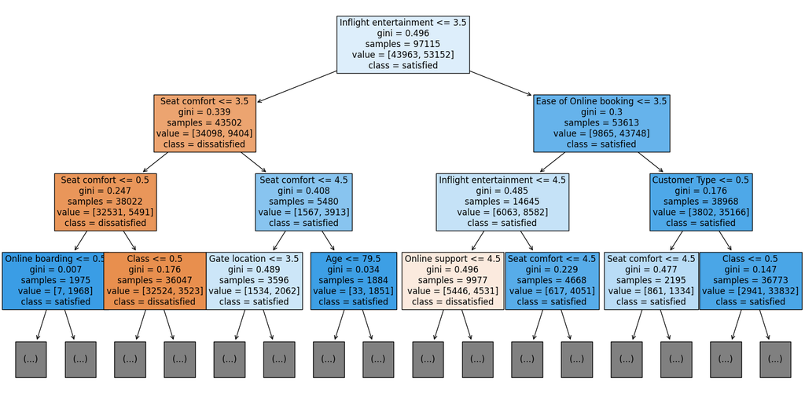

```python
# Plot tree
plt.figure(figsize=(20,10))
plot_tree(decision_tree, max_depth=3, fontsize=12, feature_names=X.columns,
          class_names={0:'dissatisfied', 1:'satisfied'}, filled=True); # filled=True gives colors
plt.show()
```

**Will a future customer would be satisfied with their services given previous customer feedback?**

The 1st line in each node(box) gives: the feature and split point that the model identified as being most predictive  
In this case, it asks if the Inflight entertainment score was <= to 3.5?

The 2nd line gives the gini impurity rating, which can range from 0 to 0.5

- 0 = there is no impurity (all samples in the leaf) are of a single class)
- 0.5 = the classes are all equally represented in that node In this case Inflight entertainment is represented very evenly

The 3rd line gives the number of samples in the node ([43963 (dissatisfied), 53152 (satisfied)] = 97115) This tells us that 43963 customers in this node were dissatisfied (y=0) and 53152 customers were satisfied (y=1) (with the entertainment).

The 4th line gives the majority class of the samples in each node: satisfied

**Conclusion**  
This tree informs that the most predictive feature for classifying if a person was satisfied is Inflight entertainment.  
Following down the tree, the next splits are at Seat Comfort and Ease of online booking, demonstrating that they are the second most predictive features.  
Near purity does not happen until a depth of 3.  
Because Seat Comfort and Ease of online booking are features 2nd in predictability and very striated, it would be good to perform further analytics on them.

### Calculate and plot feature importance

- Calculate the relative importances of each feature
- plot the results

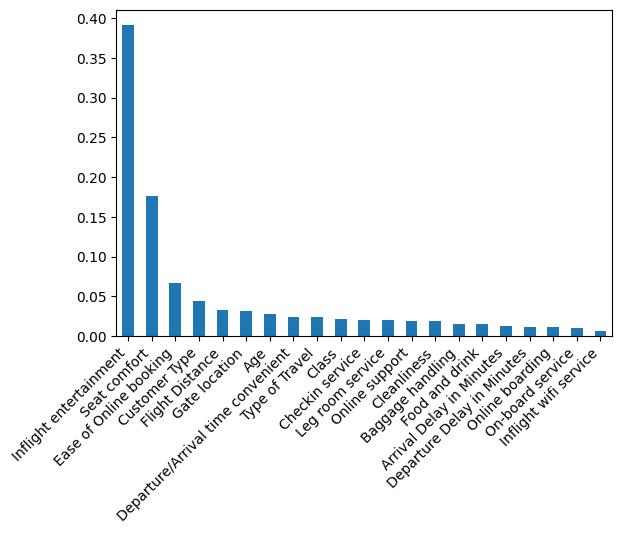

```python
# Calculate feature importance and plot results
importances = decision_tree.feature_importances_
forest_importances = pd.Series(importances, index=X.columns).sort_values(ascending=False)
fig, ax = plt.subplots()
fig.autofmt_xdate()
forest_importances.plot.bar(rot=45);
```

#### Summary

Calculating and plotting feature importances aggregated the results seen in the plotted tree. 'Inflight entertainment' is the most important feature with 'Seat comfort' being rather important. 'Ease of Online booking' is not as predictive as originally suggestive. It is slightly more predictive than the remaining variables, which are all fairly equally in productivity.  
No one seems interested in Inflight WiFi service.  
Perhaps surprisingly, for this model, delays of either sort did not weigh heavily in predictability.

### Tune Tree: hyperparameter tuning

Even though baseline tree performed excellently, tune for maximum predictability.

- instantiate decision tree
- define hyperparameters
- define scoring criteria: use f1 as metric
- instantiate & construct GridSearch cross-validation
- fit model to training data

```python
# Instatiate model
tuned_decision_tree = DecisionTreeClassifier(random_state=0)

# Determine set of hyperparameters
tree_para = {'max_depth':[1,2,3,4,5,6,7,8,9,10,20,30],
             'min_samples_leaf': [2,3,4,5,6,7,10]
            }

# Define scoring criteria: use f1 as metric
scoring = ['accuracy', 'precision', 'recall', 'f1'] # this can't be {} or throws an error. GridSearchCV only allows types: str, callable, list, tuple or dict
```

```python
# Pass to GridsearchCV
clf = GridSearchCV(tuned_decision_tree, # clf = classifier
                   tree_para,
                   scoring = scoring,
                   cv=5, # 5 cross validation folds
                   refit='f1') # refit='f1' to optimize f1

# Fit model to data
%time
clf.fit(X_train, y_train)
```

```
CPU times: user 1 µs, sys: 1 µs, total: 2 µs
Wall time: 6.2 µs
```

```
GridSearchCV(cv=5, estimator=DecisionTreeClassifier(random_state=0),
             param_grid={'max_depth': [1, 2, 3, 4, 5, 6, 7, 8, 9, 10, 20, 30],
                         'min_samples_leaf': [2, 3, 4, 5, 6, 7, 10]},
             refit='f1', scoring=['accuracy', 'precision', 'recall', 'f1'])
```

```python
# Apply settings
clf.best_estimator_
```

```
DecisionTreeClassifier(max_depth=20, min_samples_leaf=2, random_state=0)
```

```python
# Determine best average validation score
clf.best_score_
```

```
0.9445117394564206
```

#### Create metrics results table function

1st: create new df

- results = pd.DataFrame(columns=[]) 2nd: define function using make_results(model_name, model_object)
- get all the results from the CV and put them in a df
- isolate the row of the df with the max(mean f1 score)
- extract accuracy, precision, recall, and f1 score
- create table

```python
# Create a metrics results table function
results = pd.DataFrame(columns=['Model', 'Precision', 'Recall', 'Accuracy', 'F1']) # These are the cols

def make_results(model_name, model_object):  # model_name = name, model_object = clf/rf/gbx
    cv_results = pd.DataFrame(model_object.cv_results_)
    best_estimator_results = cv_results.iloc[cv_results['mean_test_f1'].idxmax(), :] # idxmax() returns a series with the index of the max value for each col
    f1 = best_estimator_results.mean_test_f1
    recall = best_estimator_results.mean_test_recall
    precision = best_estimator_results.mean_test_precision
    accuracy = best_estimator_results.mean_test_accuracy

# Create table of results
    table = pd.DataFrame({'Model': [model_name],
                          'Precision': [precision],
                          'Recall': [recall],
                          'Accuracy': [accuracy],
                          'F1': [f1]
                         })
    return table
```

```python
# Run metric results table function
TDT = make_results('Tuned Decision Tree', clf)
TDT
```

|  | Model | Precision | Recall | Accuracy | F1 |
| --- | --- | --- | --- | --- | --- |
| 0 | Tuned Decision Tree | 0.953317 | 0.935882 | 0.939814 | 0.944512 |

```python
# Read in master results table
results = pd.read_csv('Satisfaction_Results.csv')
results
```

|  | Model | Precision | Recall | Accuracy | F1 |
| --- | --- | --- | --- | --- | --- |
| 0 | DecisionTreeClassifier | 0.941512 | 0.939707 | 0.935006 | 0.940609 |
| 1 | LogisticRegression | 0.816142 | 0.821530 | 0.801529 | 0.818827 |

```python
# Concatentate decision tree model results table with master results table
results = pd.concat([TDT, results])
results
```

|  | Model | Precision | Recall | Accuracy | F1 |
| --- | --- | --- | --- | --- | --- |
| 0 | Tuned Decision Tree | 0.953317 | 0.935882 | 0.939814 | 0.944512 |
| 0 | DecisionTreeClassifier | 0.941512 | 0.939707 | 0.935006 | 0.940609 |
| 1 | LogisticRegression | 0.816142 | 0.821530 | 0.801529 | 0.818827 |

```python
# Save the master results table
results.to_csv('Satisfaction_Results.csv', index=False);

# Read in master results table
results = pd.read_csv('Satisfaction_Results.csv', index_col=0)
results
```

| Model | Precision | Recall | Accuracy | F1 |
| --- | --- | --- | --- | --- |
| Tuned Decision Tree | 0.953317 | 0.935882 | 0.939814 | 0.944512 |
| DecisionTreeClassifier | 0.941512 | 0.939707 | 0.935006 | 0.940609 |
| LogisticRegression | 0.816142 | 0.821530 | 0.801529 | 0.818827 |

#### Summary

The tuned tree is a well improved model over the logistic regression model, which used only the variable inflight entertainment to predict satisfaction. Tuned tree also has slightly better F1 and Precision scores. This is good because precision is a better metric in this case.  
Over all though there is no difference between the baseline tree and the tuned tree.  
(It should be noted that both the LG and Baseline tree were tested on the test data. The tuned tree will not be tested on this data unless it performs better than the next 2 models.)

### Plot tuned tree

Did the tuned model split the features differently?

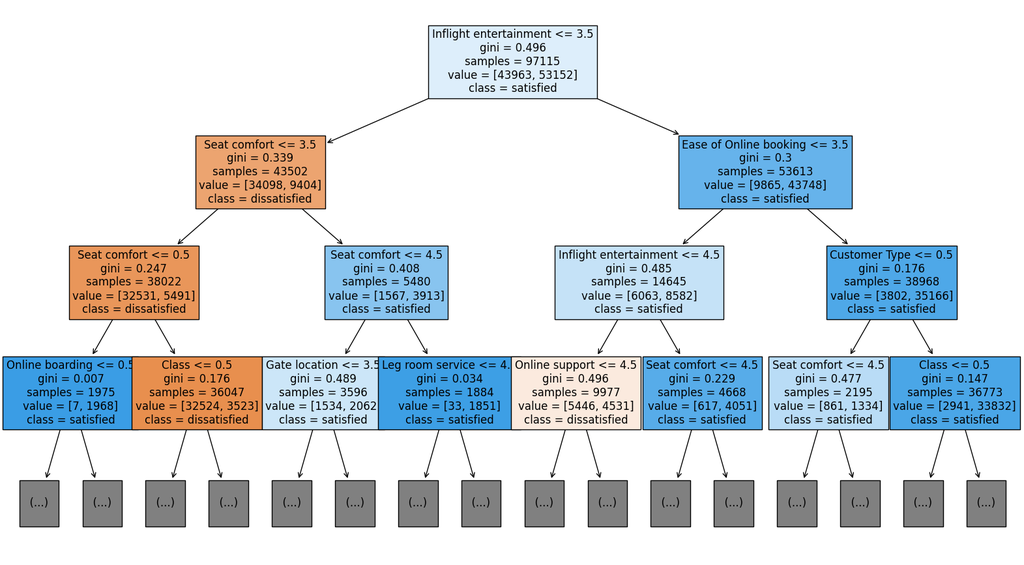

```python
# Plot tuned tree
plt.figure(figsize=(20,11))
plot_tree(clf.best_estimator_, max_depth=3, fontsize=12, feature_names=X.columns, class_names={0:'dissatisfied', 1:'satisfied'}, filled=True);
```

This model used the same features to plot (at least at first)

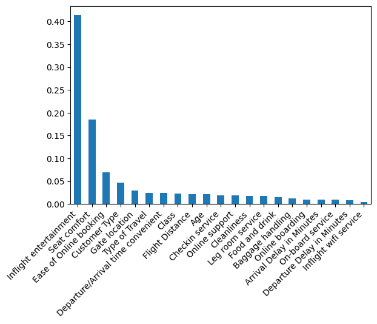

```python
# Calculate feature importance for clf.best_estimator_ parameters
importances = clf.best_estimator_.feature_importances_
forest_importances = pd.Series(importances, index=X.columns).sort_values(ascending=False)
fig, ax = plt.subplots()
fig.autofmt_xdate()
forest_importances.plot.bar(rot=45);
```

#### Results

The tuned model weighted Inflight entertainment even more heavily as a predictive feature. Inflight Wifi was essentially meaningless. Seat comfort and Ease of online booking were weighted about the same as previously.

### 2. Build a Random Forest Classifier model

```python
# Import data
df = pd.read_csv('transformed_invistico2.csv')
df.head()
```

|  | Satisfaction | Customer Type | Age | Type of Travel | Class | Flight Distance | Seat comfort | Departure/Arrival time convenient | Food and drink | Gate location | Inflight wifi service | Inflight entertainment | Online support | Ease of Online booking | On-board service | Leg room service | Baggage handling | Checkin service | Cleanliness | Online boarding | Departure Delay in Minutes | Arrival Delay in Minutes |
| --- | --- | --- | --- | --- | --- | --- | --- | --- | --- | --- | --- | --- | --- | --- | --- | --- | --- | --- | --- | --- | --- | --- |
| 0 | 1 | 1.0 | 65 | 0.0 | 0.0 | 265 | 0 | 0 | 0 | 2 | 2 | 4.0 | 2 | 3 | 3 | 0 | 3 | 5 | 3 | 2 | 0.0 | 0.0 |
| 1 | 1 | 1.0 | 47 | 0.0 | 1.0 | 2464 | 0 | 0 | 0 | 3 | 0 | 2.0 | 2 | 3 | 4 | 4 | 4 | 2 | 3 | 2 | 310.0 | 305.0 |
| 2 | 1 | 1.0 | 15 | 0.0 | 0.0 | 2138 | 0 | 0 | 0 | 3 | 2 | 0.0 | 2 | 2 | 3 | 3 | 4 | 4 | 4 | 2 | 0.0 | 0.0 |
| 3 | 1 | 1.0 | 60 | 0.0 | 0.0 | 623 | 0 | 0 | 0 | 3 | 3 | 4.0 | 3 | 1 | 1 | 0 | 1 | 4 | 1 | 3 | 0.0 | 0.0 |
| 4 | 1 | 1.0 | 70 | 0.0 | 0.0 | 354 | 0 | 0 | 0 | 3 | 4 | 3.0 | 4 | 2 | 2 | 0 | 2 | 4 | 2 | 5 | 0.0 | 0.0 |

#### Prepare data for modelling

Split the data into:

- features and target variable
- training data(75%) and test data(25%)
- no need to stratify, because data set is balanced
- set a random seed so work can be reproduced (0)

```python
# Subset data in dependent y(target) and independent X variables(features)
y = df['Satisfaction']
X = df.drop('Satisfaction', axis = 1)

# Split into train and test sets
X_train, X_test, y_train, y_test = train_test_split(X, y, test_size=0.25, random_state=0)
```

#### Build model on training data

- instantiate RF model
- define hyperparameters
- define scoring criteria: use f1 as metric
- construct GridSearch cross-validation
- fit model to training data

```python
# Instantiate RF model
rf = RandomForestClassifier(random_state=0)

# Determine set of hyperparameters
cv_params = {'max_depth' : [10, 50],
             'min_samples_leaf' : [0.5, 1, 2],
             'min_samples_split' : [0.001, 0.01, 4],
             'max_features' : ['sqrt', 2],
             'max_samples' : [.5, .9],
             'n_estimators' : [50, 100, 125]}

# Define scoring criteria: use f1 as metric
scoring = ['accuracy', 'precision', 'recall', 'f1']
```

```python
# Pass to GridsearchCV
RF_cv = GridSearchCV(rf, cv_params, scoring=scoring, cv=5, refit='f1')
```

```python
# Fit model to data
%time
RF_cv.fit(X_train, y_train)
```

```
CPU times: user 4 µs, sys: 3 µs, total: 7 µs
Wall time: 19.1 µs
```

```
GridSearchCV(cv=5, estimator=RandomForestClassifier(random_state=0),
             param_grid={'max_depth': [10, 50], 'max_features': ['sqrt', 2],
                         'max_samples': [0.5, 0.9],
                         'min_samples_leaf': [0.5, 1, 2],
                         'min_samples_split': [0.001, 0.01, 4],
                         'n_estimators': [50, 100, 125]},
             refit='f1', scoring=['accuracy', 'precision', 'recall', 'f1'])
```

```python
# Get best average score
RF_cv.best_score_
```

```
0.9574672647336804
```

```python
# Use best_params_ to get the best combination of values for the hyperparameters
RF_cv.best_params_
```

```
{'max_depth': 50,
 'max_features': 'sqrt',
 'max_samples': 0.9,
 'min_samples_leaf': 1,
 'min_samples_split': 4,
 'n_estimators': 125}
```

```python
# Call the result_table function on the model
RF_cv_results = make_results('Random Forest CV', RF_cv)
RF_cv_results
```

|  | Model | Precision | Recall | Accuracy | F1 |
| --- | --- | --- | --- | --- | --- |
| 0 | Random Forest CV | 0.965084 | 0.949974 | 0.953807 | 0.957467 |

```python
# Define a path to the folder where you want to save the model
path = ''
```

```python
# Pickle the model
with open('RF_cv_model.pickle', 'wb') as to_write: # wb = write binary
    pickle.dump(RF_cv, to_write)
```

```python
# Read in pickled model
with open('RF_cv_model.pickle', 'rb') as to_read: # rb = read binary
    RF_cv = pickle.load(to_read)
```

```python
# Read in master results table
results = pd.read_csv('Satisfaction_Results.csv')
results
```

|  | Model | Precision | Recall | Accuracy | F1 |
| --- | --- | --- | --- | --- | --- |
| 0 | Tuned Decision Tree | 0.953317 | 0.935882 | 0.939814 | 0.944512 |
| 1 | DecisionTreeClassifier | 0.941512 | 0.939707 | 0.935006 | 0.940609 |
| 2 | LogisticRegression | 0.816142 | 0.821530 | 0.801529 | 0.818827 |

```python
# Concatentate decision tree model results table with master results table
results = pd.concat([results, RF_cv_results])
results
```

```python
# Save the master results table
results.to_csv('Satisfaction_Results.csv', index=False);
```

```python
# Read in master results table
results = pd.read_csv('Satisfaction_Results.csv', index_col=0)
results
```

[output not shown]

### Tune model on validation set

- split separate validation data. Set test size to 20% to get 80% of 75%.
- create split index
- instantiate RF model
- define hyperparameters
- define scoring criteria: use f1 as metric
- construct GridSearch cross-validation
- fit model to training data

```python
# Split again into validation set
X_tr, X_val, y_tr, y_val = train_test_split(X_train, y_train, test_size=0.20, random_state=10)
```

```python
# Create list of split indices.
split_index = [0 if x in X_val.index else -1 for x in X_train.index] # select values

# Pass split index to PredefinedSplit
custom_split = PredefinedSplit(split_index)
```

```python
# Instantiate model
rf = RandomForestClassifier(random_state=0)

# Determine set of hyperparameters
cv_params = {'max_depth' : [10, 50],
             'min_samples_leaf' : [0.5, 1, 2],
             'min_samples_split' : [0.001, 0.01, 4],
             'max_features' : ['sqrt', 2],
             'max_samples' : [.5, .9],
             'n_estimators' : [50, 100, 125]}  # max # of base learners that the ensemble will grow

# Define scoring criteria: use f1 as metric
scoring = ['accuracy', 'precision', 'recall', 'f1']
```

```python
# Pass to GridsearchCV
# Set n_jobs = -1 to maximize computational efficiency
# Set verbose = 1 to track the progress of the grid search
# , n_jobs = -1, verbose = 1
RF_val = GridSearchCV(rf, cv_params, cv=custom_split, refit='f1')
```

```python
# Fit model to data
%time
RF_val.fit(X_train, y_train)
```

```
CPU times: user 2 µs, sys: 1e+03 ns, total: 3 µs
Wall time: 18.8 µs
```

```
GridSearchCV(cv=PredefinedSplit(test_fold=array([-1, -1, ..., -1, -1])),
             estimator=RandomForestClassifier(random_state=0),
             param_grid={'max_depth': [10, 50], 'max_features': ['sqrt', 2],
                         'max_samples': [0.5, 0.9],
                         'min_samples_leaf': [0.5, 1, 2],
                         'min_samples_split': [0.001, 0.01, 4],
                         'n_estimators': [50, 100, 125]},
             refit='f1')
```

```python
# Determine best average validation score
RF_val.best_score_
```

```
0.9535087267672347
```

```python
# Determine hyperparameters that yield the highest performance (settings that make the model perform the best)
RF_val.best_params_
```

```
{'max_depth': 50,
 'max_features': 'sqrt',
 'max_samples': 0.9,
 'min_samples_leaf': 1,
 'min_samples_split': 4,
 'n_estimators': 125}
```

```python
# Pickle the model
with open('RF_val_model.pickle', 'wb') as to_write: # wb = write binary
    pickle.dump(RF_val, to_write)
```

```python
# Read in pickled model
with open('RF_val_model.pickle', 'rb') as to_read: # rb = read binary
    RF_val = pickle.load(to_read)
```

```python
# Call the result_table function on the model
RF_val_results = make_results('Random Forest Val', RF_val)
RF_val_results
```

```python
# Define a path to the folder where you want to save the model
path = ''
```

```python
# Read in master results table
results = pd.read_csv('Satisfaction_Results.csv')
results
```

|  | Model | Precision | Recall | Accuracy | F1 |
| --- | --- | --- | --- | --- | --- |
| 0 | Random Forest CV | 0.965084 | 0.949974 | 0.953807 | 0.957467 |
| 1 | Tuned Decision Tree | 0.953316 | 0.935882 | 0.939813 | 0.944511 |
| 2 | DecisionTreeClassifier | 0.941512 | 0.939707 | 0.935006 | 0.940609 |
| 3 | LogisticRegression | 0.816142 | 0.821530 | 0.801529 | 0.818827 |

```python
# Concatentate decision tree model results table with master results table
results = pd.concat([results, RF_val_results])
results
```

```python
# Save the master results table
results.to_csv('Satisfaction_Results.csv', index=False)
```

```python
# Read in master results table
results = pd.read_csv('Satisfaction_Results.csv', index_col=0)
results
```

[output not shown]

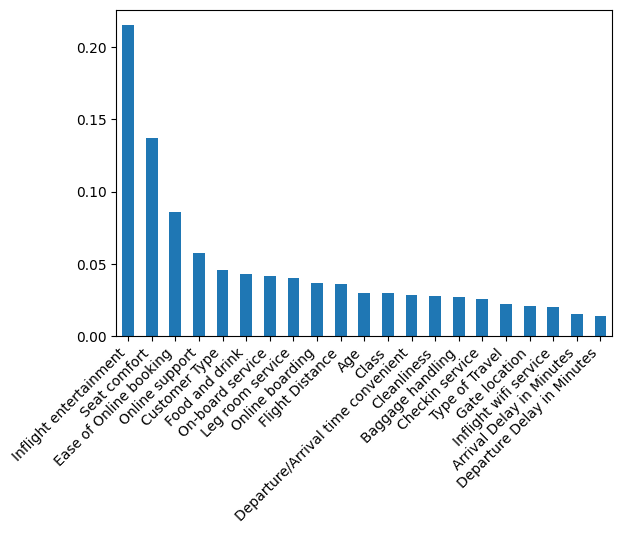

```python
# Calculate feature importance for clf.best_estimator_ parameters
importances = RF_val.best_estimator_.feature_importances_
forest_importances = pd.Series(importances, index=X.columns).sort_values(ascending=False)
fig, ax = plt.subplots()
fig.autofmt_xdate()
forest_importances.plot.bar(rot=45);
```

## 3. Build an XGBoost model

```python
# Import data
df = pd.read_csv('transformed_invistico2.csv')
df.head()
```

|  | Satisfaction | Customer Type | Age | Type of Travel | Class | Flight Distance | Seat comfort | Departure/Arrival time convenient | Food and drink | Gate location | Inflight wifi service | Inflight entertainment | Online support | Ease of Online booking | On-board service | Leg room service | Baggage handling | Checkin service | Cleanliness | Online boarding | Departure Delay in Minutes | Arrival Delay in Minutes |
| --- | --- | --- | --- | --- | --- | --- | --- | --- | --- | --- | --- | --- | --- | --- | --- | --- | --- | --- | --- | --- | --- | --- |
| 0 | 1 | 1.0 | 65 | 0.0 | 0.0 | 265 | 0 | 0 | 0 | 2 | 2 | 4.0 | 2 | 3 | 3 | 0 | 3 | 5 | 3 | 2 | 0.0 | 0.0 |
| 1 | 1 | 1.0 | 47 | 0.0 | 1.0 | 2464 | 0 | 0 | 0 | 3 | 0 | 2.0 | 2 | 3 | 4 | 4 | 4 | 2 | 3 | 2 | 310.0 | 305.0 |
| 2 | 1 | 1.0 | 15 | 0.0 | 0.0 | 2138 | 0 | 0 | 0 | 3 | 2 | 0.0 | 2 | 2 | 3 | 3 | 4 | 4 | 4 | 2 | 0.0 | 0.0 |
| 3 | 1 | 1.0 | 60 | 0.0 | 0.0 | 623 | 0 | 0 | 0 | 3 | 3 | 4.0 | 3 | 1 | 1 | 0 | 1 | 4 | 1 | 3 | 0.0 | 0.0 |
| 4 | 1 | 1.0 | 70 | 0.0 | 0.0 | 354 | 0 | 0 | 0 | 3 | 4 | 3.0 | 4 | 2 | 2 | 0 | 2 | 4 | 2 | 5 | 0.0 | 0.0 |

#### Prepare data for modelling

- split data into separate test and training sets

```python
# Subset data in dependent y(target) and independent X variables(features)
y = df['Satisfaction']
X = df.drop('Satisfaction', axis = 1)

# Split into train and test sets
X_train, X_test, y_train, y_test = train_test_split(X, y, test_size=0.25, random_state=0)
```

#### Modelling

- instantiate model
- define hyperparameters
- define scoring criteria: use f1 as metric
- construct GridSearch cross-validation
- fit model to training data

```python
# Instantiate XGBClassifier.
# Set the objective = binary:logistic
XGB = XGBClassifier(objective='binary:logistic', random_state=0)
```

```python
# Determine set of cross-validated hyperparameters
cv_params = {'max_depth': [4, 6],
             'min_child_weight': [1, 2, 3],
             'learning_rate': [0.1, 0.2, 0.3],
             'n_estimators': [5, 10, 15],
             'subsample': [0.7],
             'colsample_bytree': [0.7]
            }

# Define scoring criteria: use f1 as metric
scoring = ['accuracy', 'precision', 'recall', 'f1']

# Pass to GridsearchCV
XGB_cv = GridSearchCV(XGB, cv_params, scoring=scoring, cv=5, refit='f1', n_jobs = -1, verbose = 1)
```

```python
%time
# fit the GridSearch model to training data
XGB_cv.fit(X_train, y_train)
```

```
CPU times: user 3 µs, sys: 0 ns, total: 3 µs
Wall time: 4.77 µs
Fitting 5 folds for each of 54 candidates, totalling 270 fits
```

```
GridSearchCV(cv=5,
             estimator=XGBClassifier(base_score=None, booster=None,
                                     callbacks=None, colsample_bylevel=None,
                                     colsample_bynode=None,
                                     colsample_bytree=None, device=None,
                                     early_stopping_rounds=None,
                                     enable_categorical=False, eval_metric=None,
                                     feature_types=None, gamma=None,
                                     grow_policy=None, importance_type=None,
                                     interaction_constraints=None,
                                     learning_rate=None,...
                                     missing=nan, monotone_constraints=None,
                                     multi_strategy=None, n_estimators=None,
                                     n_jobs=None, num_parallel_tree=None,
                                     random_state=0, ...),
             n_jobs=-1,
             param_grid={'colsample_bytree': [0.7],
                         'learning_rate': [0.1, 0.2, 0.3], 'max_depth': [4, 6],
                         'min_child_weight': [1, 2, 3],
                         'n_estimators': [5, 10, 15], 'subsample': [0.7]},
             refit='f1', scoring=['accuracy', 'precision', 'recall', 'f1'],
             verbose=1)
```

```python
# Find optimal set of parameters
XGB_cv.best_params_
```

```
{'colsample_bytree': 0.7,
 'learning_rate': 0.3,
 'max_depth': 6,
 'min_child_weight': 1,
 'n_estimators': 15,
 'subsample': 0.7}
```

```python
# Determine best average validation score
XGB_cv.best_score_
```

```
0.9369627577825661
```

```python
# Define a path to the folder where you want to save the model
path = ''
```

```python
# Pickle the model
with open('XGB_cv_model.pickle', 'wb') as to_write: # wb = write binary
    pickle.dump(XGB_cv, to_write)
```

```python
# Read in pickled model
with open('XGB_cv_model.pickle', 'rb') as to_read: # rb = read binary
    XGB_cv = pickle.load(to_read)
```

```python
# Call the result_table function on the model
XGB_cv_results = make_results('XGBoost CV', XGB_cv)
XGB_cv_results
```

|  | Model | Precision | Recall | Accuracy | F1 |
| --- | --- | --- | --- | --- | --- |
| 0 | XGBoost CV | 0.941917 | 0.932063 | 0.93136 | 0.936963 |

```python
# Read in master results table
results = pd.read_csv('Satisfaction_Results.csv')
results
```

|  | Model | Precision | Recall | Accuracy | F1 |
| --- | --- | --- | --- | --- | --- |
| 0 | Random Forest CV | 0.965084 | 0.949974 | 0.953807 | 0.957467 |
| 1 | Tuned Decision Tree | 0.953316 | 0.935882 | 0.939813 | 0.944511 |
| 2 | DecisionTreeClassifier | 0.941512 | 0.939707 | 0.935006 | 0.940609 |
| 3 | LogisticRegression | 0.816142 | 0.821530 | 0.801529 | 0.818827 |

```python
# Concatentate decision tree model results table with master results table
results = pd.concat([results, XGB_cv_results])
results
```

|  | Model | Precision | Recall | Accuracy | F1 |
| --- | --- | --- | --- | --- | --- |
| 0 | Random Forest CV | 0.965084 | 0.949974 | 0.953807 | 0.957467 |
| 1 | Tuned Decision Tree | 0.953316 | 0.935882 | 0.939813 | 0.944511 |
| 2 | DecisionTreeClassifier | 0.941512 | 0.939707 | 0.935006 | 0.940609 |
| 3 | LogisticRegression | 0.816142 | 0.821530 | 0.801529 | 0.818827 |
| 0 | XGBoost CV | 0.941917 | 0.932063 | 0.931360 | 0.936963 |

```python
# Save the master results table
results.to_csv('Satisfaction_Results.csv', index=False);
```

```python
# Read in master results table
results = pd.read_csv('Satisfaction_Results.csv', index_col=0)
results
```

| Model | Precision | Recall | Accuracy | F1 |
| --- | --- | --- | --- | --- |
| Random Forest CV | 0.965084 | 0.949974 | 0.953807 | 0.957467 |
| Tuned Decision Tree | 0.953316 | 0.935882 | 0.939813 | 0.944511 |
| DecisionTreeClassifier | 0.941512 | 0.939707 | 0.935006 | 0.940609 |
| LogisticRegression | 0.816142 | 0.821530 | 0.801529 | 0.818827 |
| XGBoost CV | 0.941917 | 0.932063 | 0.931360 | 0.936963 |

```python
# Apply settings
XGB_cv.best_estimator_
```

```
XGBClassifier(base_score=None, booster=None, callbacks=None,
              colsample_bylevel=None, colsample_bynode=None,
              colsample_bytree=0.7, device=None, early_stopping_rounds=None,
              enable_categorical=False, eval_metric=None, feature_types=None,
              gamma=None, grow_policy=None, importance_type=None,
              interaction_constraints=None, learning_rate=0.3, max_bin=None,
              max_cat_threshold=None, max_cat_to_onehot=None,
              max_delta_step=None, max_depth=6, max_leaves=None,
              min_child_weight=1, missing=nan, monotone_constraints=None,
              multi_strategy=None, n_estimators=15, n_jobs=None,
              num_parallel_tree=None, random_state=0, ...)
```

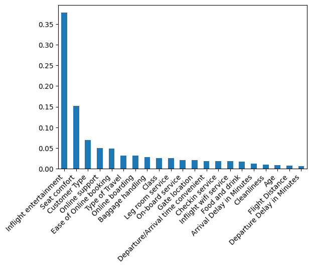

```python
# Calculate feature importance for clf.best_estimator_ parameters
importances = XGB_cv.best_estimator_.feature_importances_
forest_importances = pd.Series(importances, index=X.columns).sort_values(ascending=False)
fig, ax = plt.subplots()
fig.autofmt_xdate()
forest_importances.plot.bar(rot=45);
```

#### Results

Perhaps of note: the XGBoost did not weight seat comfort as a predictive feature as the tuned decision tree.

## Test best model

```python
# Read in master results table
results = pd.read_csv('Satisfaction_Results.csv')
results = results.sort_values(by=['F1'], ascending=False)
results
```

[output not shown]

```python
# Import data
df = pd.read_csv('transformed_invistico2.csv')
df.head()
```

|  | Satisfaction | Customer Type | Age | Type of Travel | Class | Flight Distance | Seat comfort | Departure/Arrival time convenient | Food and drink | Gate location | Inflight wifi service | Inflight entertainment | Online support | Ease of Online booking | On-board service | Leg room service | Baggage handling | Checkin service | Cleanliness | Online boarding | Departure Delay in Minutes | Arrival Delay in Minutes |
| --- | --- | --- | --- | --- | --- | --- | --- | --- | --- | --- | --- | --- | --- | --- | --- | --- | --- | --- | --- | --- | --- | --- |
| 0 | 1 | 1.0 | 65 | 0.0 | 0.0 | 265 | 0 | 0 | 0 | 2 | 2 | 4.0 | 2 | 3 | 3 | 0 | 3 | 5 | 3 | 2 | 0.0 | 0.0 |
| 1 | 1 | 1.0 | 47 | 0.0 | 1.0 | 2464 | 0 | 0 | 0 | 3 | 0 | 2.0 | 2 | 3 | 4 | 4 | 4 | 2 | 3 | 2 | 310.0 | 305.0 |
| 2 | 1 | 1.0 | 15 | 0.0 | 0.0 | 2138 | 0 | 0 | 0 | 3 | 2 | 0.0 | 2 | 2 | 3 | 3 | 4 | 4 | 4 | 2 | 0.0 | 0.0 |
| 3 | 1 | 1.0 | 60 | 0.0 | 0.0 | 623 | 0 | 0 | 0 | 3 | 3 | 4.0 | 3 | 1 | 1 | 0 | 1 | 4 | 1 | 3 | 0.0 | 0.0 |
| 4 | 1 | 1.0 | 70 | 0.0 | 0.0 | 354 | 0 | 0 | 0 | 3 | 4 | 3.0 | 4 | 2 | 2 | 0 | 2 | 4 | 2 | 5 | 0.0 | 0.0 |

```python
# Subset data in dependent y(target) and independent X variables(features)
y = df['Satisfaction']
X = df.drop('Satisfaction', axis = 1)

# Split into train and test sets
X_train, X_test, y_train, y_test = train_test_split(X, y, test_size=0.25, random_state=0)
```

```python
# Instantiate RF model
rf = RandomForestClassifier(random_state=0)

# Determine set of hyperparameters
cv_params = {'max_depth' : [50],
             'min_samples_leaf' : [1],
             'min_samples_split' : [4],
             'max_features' : ['sqrt'],
             'max_samples' : [.9],
             'n_estimators' : [125]}

# Define scoring criteria: use f1 as metric
scoring = ['accuracy', 'precision', 'recall', 'f1']
```

```python
# Pass to GridsearchCV
RF_final = GridSearchCV(rf, cv_params, scoring=scoring, cv=5, refit='f1', n_jobs = -1, verbose = 1)
```

```python
%time
# fit the GridSearch model to testing data
RF_final.fit(X_test, y_test)
```

```
CPU times: user 2 µs, sys: 1 µs, total: 3 µs
Wall time: 6.91 µs
Fitting 5 folds for each of 1 candidates, totalling 5 fits
```

```
GridSearchCV(cv=5, estimator=RandomForestClassifier(random_state=0), n_jobs=-1,
             param_grid={'max_depth': [50], 'max_features': ['sqrt'],
                         'max_samples': [0.9], 'min_samples_leaf': [1],
                         'min_samples_split': [4], 'n_estimators': [125]},
             refit='f1', scoring=['accuracy', 'precision', 'recall', 'f1'],
             verbose=1)
```

```python
# Apply your model to predict on your test data. Call this output "y_pred".
y_pred = RF_final.predict(X_test)
```

```python
# Get final metrics
print('F1 score tested Random Forest model:', '%.6f' % f1_score(y_test, y_pred))
print('Recall score tested Random Forest model:', '%.6f' % recall_score(y_test, y_pred))
print('Precision score tested Random Forest model:', '%.6f' % precision_score(y_test, y_pred))
print('Accuracy score tested Random Forest model:', '%.6f' % accuracy_score(y_test, y_pred))
```

```
F1 score tested Random Forest model: 0.996722
Recall score tested Random Forest model: 0.994698
Precision score tested Random Forest model: 0.998754
Accuracy score tested Random Forest model: 0.996417
```

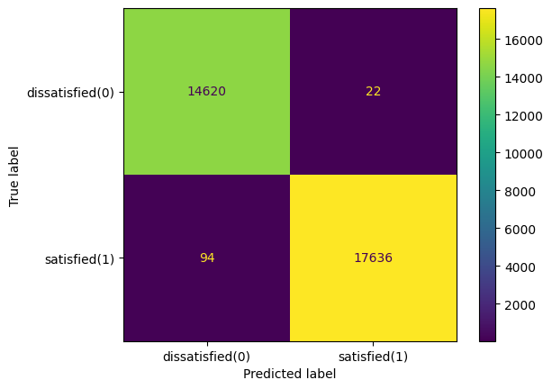

```python
# Create confusion matrix to visualize how accurate classifier is at predicting the labels for a categorical variable
# Calculate the values for each quadrant in the confusion matrix
cm = confusion_matrix(y_test, y_pred, labels = RF_final.classes_) # clf.classes_ (classifications)

# Visualize confusion matrix
disp = ConfusionMatrixDisplay(confusion_matrix = cm,display_labels=['dissatisfied(0)', 'satisfied(1)']) #display_labels = clf.classes_

disp.plot();
```

*Translation*

- True negatives(UL): # of people that were dissatisfied(0) that the model accurately predicted as dissatisfied(0) = 14620
- True positives(LR): # of people that were satisfied(1) that the model accurately predicted were satisfied(1) = 17636
- False positives(UR)/ Type I Errors: # of people that were dissatisfied(0) that the model inaccurately predicted were satisfied(1) = 22
- False negatives(LL)/Type II Errors: # of people that were satisfied(1) that the model inaccurately predicted were dissatisfied(0) = 94

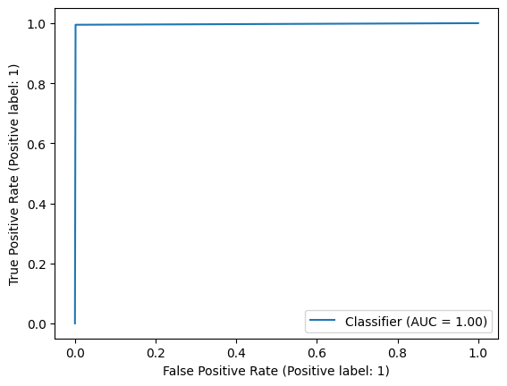

```python
# Plot ROC curve
RocCurveDisplay.from_predictions(y_test, y_pred)
plt.show()
```

```python
# Compute the AUC
roc_auc_score(y_test,y_pred)
```

```
0.9965978622869273
```

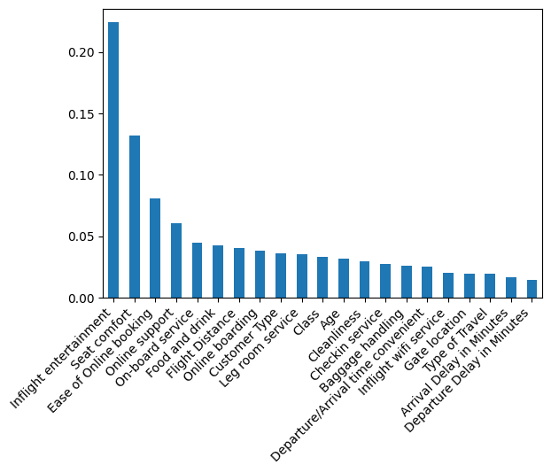

```python
# Calculate feature importance for clf.best_estimator_ parameters
importances = RF_final.best_estimator_.feature_importances_
forest_importances = pd.Series(importances, index=X.columns).sort_values(ascending=False)
fig, ax = plt.subplots()
fig.autofmt_xdate()
forest_importances.plot.bar(rot=45);
```

# Results of Best Decision Model: Random Forest

The objective of this random forest model is to predict whether a future customer would be satisfied with all of Invistico airlines services given previous customer feedback about their total flight experiences and to uncover which features of a customer’s airline experience were most predictive of their satisfaction. Unlike the previously built logistic regression model (PART I), which used only the variable *Inflight entertainment* as the independent predictive variable to predicate whether the inflight entertainment experiences of previous customers can indicate future customer satisfaction, this random forest model maximizes predictability by using all features (independent Xs) present in the data set. The model performs supremely. Using the dependent binary variable *Satisfaction* the model predicts with a near 100% accuracy score which customers will be satisfied (and dissatisfied) based on all features.

On the whole, previous customers were fairly split in their satisfaction with their overall experience of the airline. ~55% of customers were satisfied and ~45% were dissatisfied. Out of the 32372 people in the test data, 17730 were satisfied. Of these, the model missed only 94 satisfied people, thereby achieving a ~99% recall score. The model also scored ~100% on precision (with a f1 of ~100%), thus it has an equally high ability to identify satisfied or unsatisfied customers and an equally low chance of falsely identifying satisfied or unsatisfied customers (Type I and Type II errors). Further demonstrating this model's efficacy, it achieved an AUC score of ~100%, which suggests a near perfect performance over all possible classification thresholds in distinguishing between positive and negative classes.

Because the model scored so highly in all metrics, it is difficult to suggest further optimization. Optimizing either precision or recall scores, would likely result in either more false positives, where it would attempt to reduce the occurrences of incorrectly classifying people as satisfied when they are dissatisfied (Type I errors) or more false-negatives where more people would be classified as dissatisfied, when then are satisfied (Type II errors).

The most predictive feature in customer satisfaction as ascertained by the model was inflight entertainment, with seat comfort and ease of online booking also being somewhat predictive. Inflight wifi service was not the least predictive variable as it had been in non-winning models; however, perhaps surprisingly, delays either in arrival or departure had the lowest predictive effect. The extreme success of the model indicates that the airline should focus attention on their inflight entertainment service, either leaving it as it is or continuing to improve it based on customer feedback. As the model scored an ~100% on accuracy, this is far better predictor than the ~55% satisfaction rating for the overall dataset.